# ggsolvencyii

The goal of ggsolvencyii is to show the buildup (“build-down”) of the Solvency II SCR from the individual risks, whether for standard formula or (partial) intern models.

## status

[figure not shown]

[figure not shown]

## Installation

You can install ggsolvencyii from Github:

```r
# install.packages("devtools")
devtools::install_github("vanzanden/ggsolvencyii")
# or from the binary in github.com/vanzanden/ggsolvencyii/binaries/windows
```

## short version

This README is a short version of the vignette ‘ggsolvencyii’ at https://github.com/vanzanden/ggsolvencyii/tree/master/ which shows more code. the annotated code of the first example is shown in vignette ‘showcase’.

## example

ggsolvencyii builds on ggplot-functionality and provides three geom’s: `geom_sii_risksurface`, `geom_sii_riskoutline` and `geom_sii_riskconnection`

These three goem’s were used to produce the following plot which for example could be used for an ORSA report.

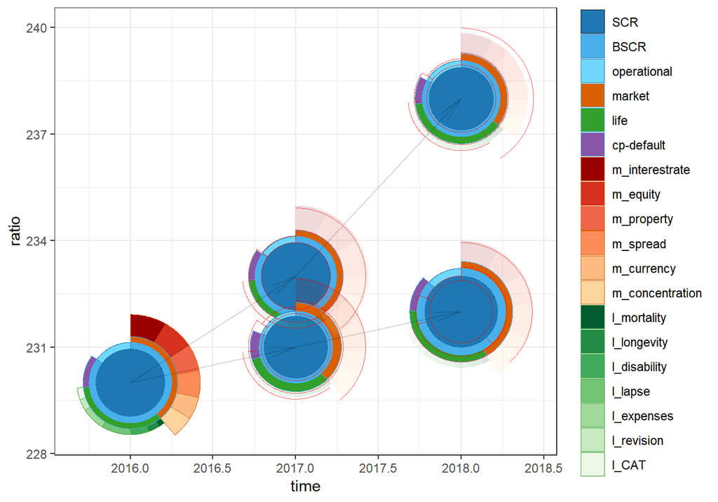

```
#> [1] "scaling is based on inputvalue (maxscrvalue) of 25.7433642812936"
#> [1] "scaling is based on a max (level= 1) value of 25.7433642812936"
#> [1] "scaling is based on a max (level= 1) value of 25.7433642812936"
#> [1] "scaling is based on a max (level= 1) value of 25.7433642812936"
```

The total surface (to the centerpoint of each circle) of the outer segments show the size of undiversified risks. Diversification is made visible by the difference between the risk segment and the next segment nearer to the center of the plot. The red (out)lines are displayed for comparison with the previous SCR buildup.

## Baseplot and options

### base

An life insurer reports its solvency ratio following Standard Formula rules, with English names for all risks. It has a set of risks, diversification effects, and accumulations to the SCR for the current situation (‘id’=1) and two two-year ORSA scenarios. The SCR composition of the current situation (id = 1) is shown below where `sii_z_ex1_data` a tidyverse transformation is of the data.

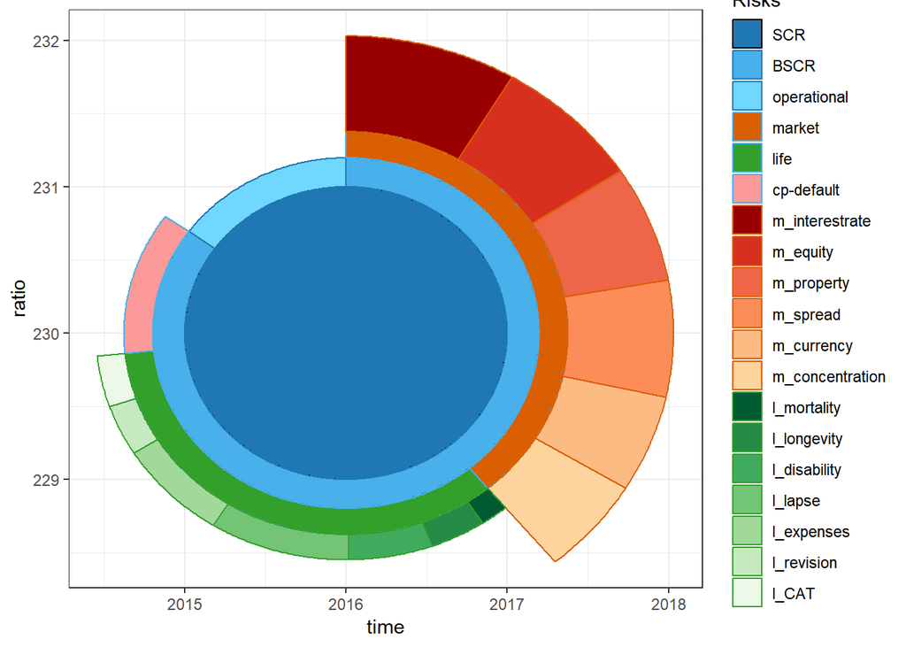

```
#> [1] "scaling is based on a max (level= 1) value of 23"
```

```r
ggplot() +
  geom_sii_risksurface(
    data = sii_z_ex1_data[sii_z_ex1_data$id == 1, ],
    mapping = aes(x = time, y = ratio, id = id, value = value,
                           description = description,
                           fill = description, color = description) ) +
theme_bw() +
scale_fill_manual(name = "Risks",values = sii_x_fillcolors_sf16_eng) +
scale_color_manual(name = "Risks",values = sii_x_edgecolors_sf16_eng)
```

### structure

`Geom_sii_risksurface` uses one default table for this plot `sii_structure_sf16_eng`. It defines each risks by indicating from which combined ‘child’-risks and diversification (suffix ‘d’) it is made up. Passing another structure table makes this geom usable for localisation or for internal models.

### levelmax

To prevent cluttering of the legend it is possible to group the smallest items of a level by providing a levelmax-table in such a way that the indicated maximum items in that level is not exceded. the example is on another dataset `sii_z_ex2_data`, with only one SCR result.

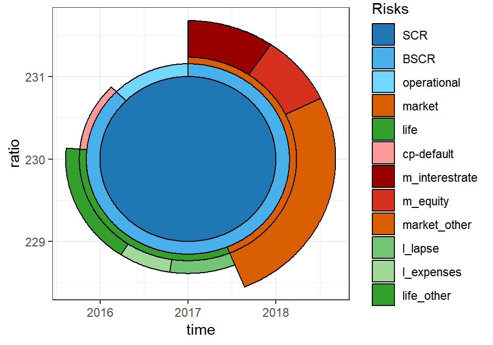

```
#> [1] "scaling is based on a max (level= 1) value of 30"
```

### Rotation and squared

`rotationdescription` Rotates the plot in such a way that the indicated item (can be on either level, i.e. works also on ‘life’ or ‘operational’) is plotted on just on the righthandside of ‘12 o’clock’. `rotationdegrees’ provides an added rotation. The example rotates ‘m_equity’ to 12 ’o clock, and then 45 degrees counter clockwise.

The option ‘squared’ makes a square plot, with the surface of all segments still in proportion.

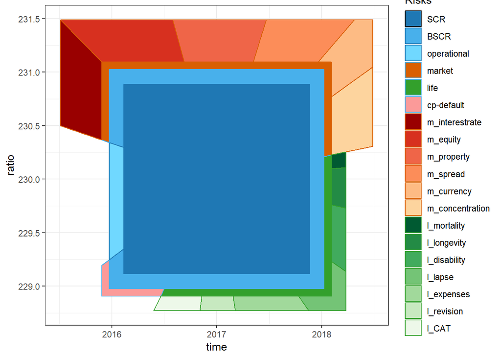

```
#> [1] "scaling is based on a max (level= 1) value of 30"
#> [1] "for id = 1 the description dependent rotation is : 325.945945945946 degrees"
```

The second plot shows a comparison between a circle and square plot of the same data. Note that the radius of the SCR circle is smaller than the size of the SCR square and that angles are different because in the corners there is ‘additional’ surface available compared to a circle.

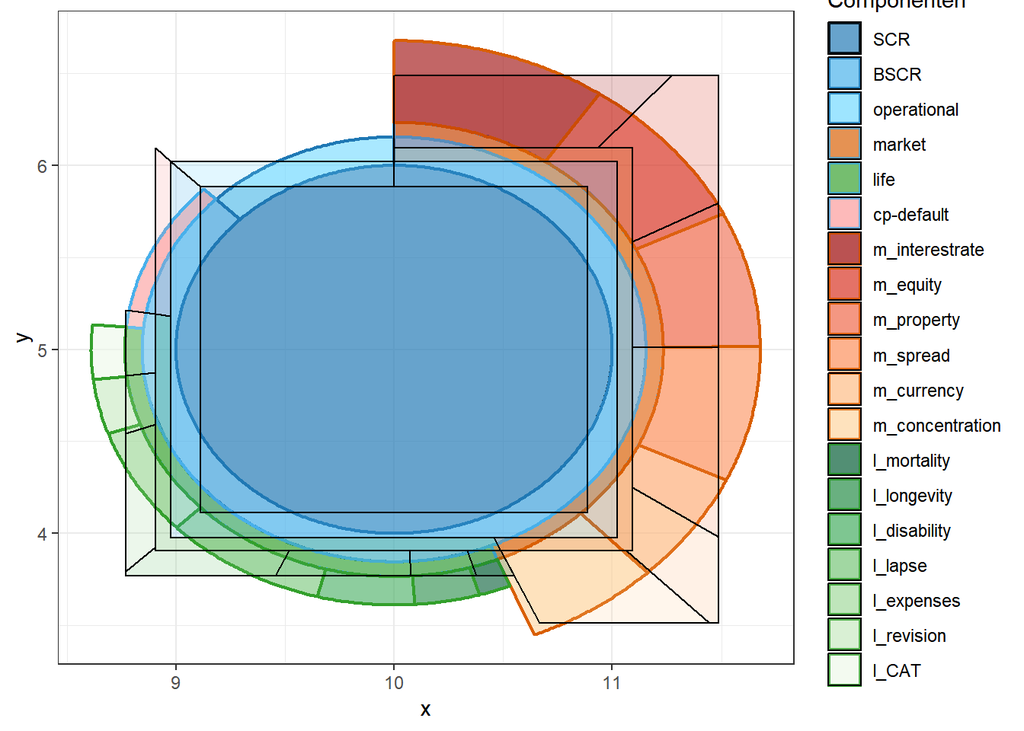

```
#> [1] "scaling is based on a max (level= 1) value of 30"
#> [1] "scaling is based on a max (level= 1) value of 30"
```

## additional parameters

additional parameters, some in the form of tables, can be used for determing what parts of the calculated circle-segments to plot (‘plotdetails’), scaling (‘maxscrvalue’, ‘scalingx’, ‘scalingy’), or for easy comparison between two instances of a SCR buildup (aesthetic ‘comparewithid’).